# Practical Machine Learning Assignment

Sam

Thursday, August 25, 2016

# Background

Using devices such as Jawbone Up, Nike FuelBand, and Fitbit it is now possible to collect a large amount of data about personal activity relatively inexpensively. These type of devices are part of the quantified self movement - a group of enthusiasts who take measurements about themselves regularly to improve their health, to find patterns in their behavior, or because they are tech geeks. One thing that people regularly do is quantify how much of a particular activity they do, but they rarely quantify how well they do it. In this project, your goal will be to use data from accelerometers on the belt, forearm, arm, and dumbell of 6 participants. They were asked to perform barbell lifts correctly and incorrectly in 5 different ways. More information is available from the website here: http://groupware.les.inf.puc-rio.br/har (see the section on the Weight Lifting Exercise Dataset).

# Data

The training data for this project are available here:

https://d396qusza40orc.cloudfront.net/predmachlearn/pml-training.csv

The test data are available here:

https://d396qusza40orc.cloudfront.net/predmachlearn/pml-testing.csv

The data for this project come from this source: http://groupware.les.inf.puc-rio.br/har. If you use the document you create for this class for any purpose please cite them as they have been very generous in allowing their data to be used for this kind of assignment.

# Load the data and clean

```r
setwd("D:\\My Projects\\1 - STAM TEG\\22 - Coursera\\14 - Coursera Practical Machine Learning\\1 - Project Assignment")

trainOrg = read.csv("pml-training.csv", na.strings=c("", "NA", "NULL"))
testOrg = read.csv("pml-testing.csv", na.strings=c("", "NA", "NULL"))

dim(trainOrg)
```

```
## [1] 19622   160
```

```r
dim(testOrg)
```

```
## [1]  20 160
```

```r
training.dn <- trainOrg[ , colSums(is.na(trainOrg)) == 0]
dim(training.dn)
```

```
## [1] 19622    60
```

```r
rem = c('X', 'user_name', 'raw_timestamp_part_1', 'raw_timestamp_part_2', 'cvtd_timestamp', 'new_window', 'num_window')


training.dr <- training.dn[, -which(names(training.dn) %in% rem)]
dim(training.dr)
```

```
## [1] 19622    53
```

```r
library(caret)
# Evaluating NonZero variables
zeroVar= nearZeroVar(training.dr[sapply(training.dr, is.numeric)], saveMetrics = TRUE)
training.nonzerovar = training.dr[,zeroVar[, 'nzv']==0]
dim(training.nonzerovar)
```

```
## [1] 19622    53
```

```r
# Evaluating NonZero Variables
corrMat <- cor(na.omit(training.nonzerovar[sapply(training.nonzerovar, is.numeric)]))
dim(corrMat)
```

```
## [1] 52 52
```

```r
corrDF <- expand.grid(row = 1:52, col = 1:52)
corrDF$correlation <- as.vector(corrMat)
```

# Plot 1

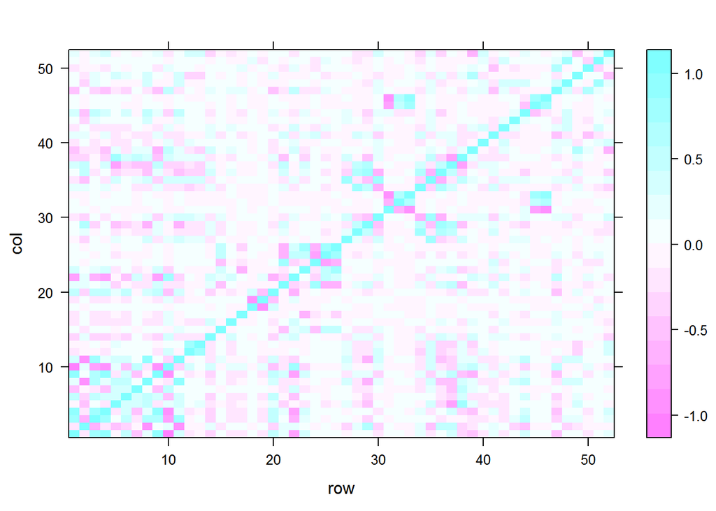

```r
levelplot(correlation ~ row+ col, corrDF)
```

```r
removecor = findCorrelation(corrMat, cutoff = .90, verbose = TRUE)
```

```
## Compare row 10  and column  1 with corr  0.992
##   Means:  0.27 vs 0.168 so flagging column 10
## Compare row 1  and column  9 with corr  0.925
##   Means:  0.25 vs 0.164 so flagging column 1
## Compare row 9  and column  4 with corr  0.928
##   Means:  0.233 vs 0.161 so flagging column 9
## Compare row 8  and column  2 with corr  0.966
##   Means:  0.245 vs 0.157 so flagging column 8
## Compare row 19  and column  18 with corr  0.918
##   Means:  0.091 vs 0.158 so flagging column 18
## Compare row 46  and column  31 with corr  0.914
##   Means:  0.101 vs 0.161 so flagging column 31
## Compare row 46  and column  33 with corr  0.933
##   Means:  0.083 vs 0.164 so flagging column 33
## All correlations <= 0.9
```

```r
train.decor = training.nonzerovar[,-removecor]
dim(train.decor)
```

```
## [1] 19622    46
```

# Slice the data

Training set split into two for cross validation purposes. Randomly sub sampling 70 pecent of the set for training while the 30 percent for testing.

```r
inTrain <- createDataPartition(y=train.decor$classe, p=0.7, list=FALSE)
training <- train.decor[inTrain,]; testing <- train.decor[-inTrain,]
dim(training);dim(testing)
```

```
## [1] 13737    46
```

```
## [1] 5885   46
```

```r
library(tree)
set.seed(10305)
tree.training=tree(classe~.,data=training)
summary(tree.training)
```

```
##
## Classification tree:
## tree(formula = classe ~ ., data = training)
## Variables actually used in tree construction:
##  [1] "pitch_forearm"     "magnet_belt_y"     "accel_forearm_z"
##  [4] "magnet_dumbbell_y" "roll_forearm"      "magnet_dumbbell_z"
##  [7] "accel_dumbbell_y"  "pitch_belt"        "yaw_belt"
## [10] "accel_forearm_x"   "accel_dumbbell_z"  "yaw_forearm"
## [13] "magnet_forearm_z"  "magnet_arm_x"      "gyros_belt_z"
## Number of terminal nodes:  27
## Residual mean deviance:  1.413 = 19370 / 13710
## Misclassification error rate: 0.2634 = 3618 / 13737
```

```r
library(caret)
modFit <- train(classe ~ .,method="rpart",data=training)
print(modFit$finalModel)
```

```
## n= 13737
##
## node), split, n, loss, yval, (yprob)
##       * denotes terminal node
##
##  1) root 13737 9831 A (0.28 0.19 0.17 0.16 0.18)
##    2) pitch_forearm< -34 1090    6 A (0.99 0.0055 0 0 0) *
##    3) pitch_forearm>=-34 12647 9825 A (0.22 0.21 0.19 0.18 0.2)
##      6) magnet_belt_y>=555.5 11630 8809 A (0.24 0.23 0.21 0.18 0.15)
##       12) magnet_dumbbell_y< 438.5 9692 6937 A (0.28 0.18 0.24 0.17 0.12)
##         24) roll_forearm< 123.5 6137 3652 A (0.4 0.18 0.19 0.14 0.088) *
##         25) roll_forearm>=123.5 3555 2374 C (0.076 0.19 0.33 0.22 0.19)
##           50) accel_forearm_x>=-107.5 2521 1583 C (0.084 0.23 0.37 0.091 0.22) *
##           51) accel_forearm_x< -107.5 1034  484 D (0.055 0.085 0.24 0.53 0.093) *
##       13) magnet_dumbbell_y>=438.5 1938 1032 B (0.034 0.47 0.036 0.21 0.26) *
##      7) magnet_belt_y< 555.5 1017  191 E (0.00098 0.0029 0.00098 0.18 0.81) *
```

```r
tree.pred=predict(tree.training,testing,type="class")
predMatrix = with(testing,table(tree.pred,classe))

sum(diag(predMatrix))/sum(as.vector(predMatrix))
```

```
## [1] 0.7401869
```

```r
tree.pred=predict(modFit,testing)
predMatrix = with(testing,table(tree.pred,classe))

#Error Rate
sum(diag(predMatrix))/sum(as.vector(predMatrix))
```

```
## [1] 0.5026338
```

```r
cv.training=cv.tree(tree.training,FUN=prune.misclass)
cv.training
```

```
## $size
##  [1] 27 26 25 22 20 19 18 17 16 13  7  5  1
##
## $dev
##  [1] 4177 4187 4289 4712 4764 5135 5269 5414 5414 6522 6592 7278 9831
##
## $k
##  [1]     -Inf  50.0000  88.0000 119.3333 124.0000 136.0000 144.0000
##  [8] 152.0000 155.0000 200.6667 201.5000 256.0000 639.7500
##
## $method
## [1] "misclass"
##
## attr(,"class")
## [1] "prune"         "tree.sequence"
```

# Plot 2

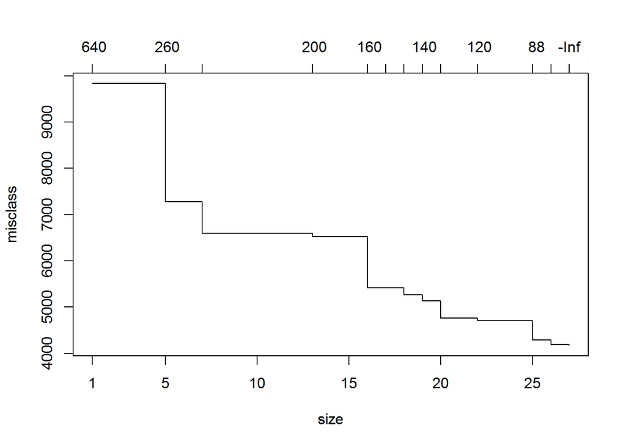

```r
plot(cv.training)
```

```r
prune.training=prune.misclass(tree.training,best=18)
tree.pred=predict(prune.training,testing,type="class")
predMatrix = with(testing,table(tree.pred,classe))

#Error Rate
sum(diag(predMatrix))/sum(as.vector(predMatrix))
```

```
## [1] 0.6679694
```

```r
require(randomForest)
set.seed(10305)

rf.training=randomForest(classe~.,data=training,ntree=100, importance=TRUE)
rf.training
```

```
##
## Call:
##  randomForest(formula = classe ~ ., data = training, ntree = 100,      importance = TRUE)
##                Type of random forest: classification
##                      Number of trees: 100
## No. of variables tried at each split: 6
##
##         OOB estimate of  error rate: 0.74%
## Confusion matrix:
##      A    B    C    D    E class.error
## A 3901    3    1    0    1 0.001280082
## B   18 2626   14    0    0 0.012039127
## C    0   15 2378    3    0 0.007512521
## D    0    0   34 2216    2 0.015985790
## E    0    0    3    7 2515 0.003960396
```

# Plot 3

Estimating the performance of the model on the validation dataset

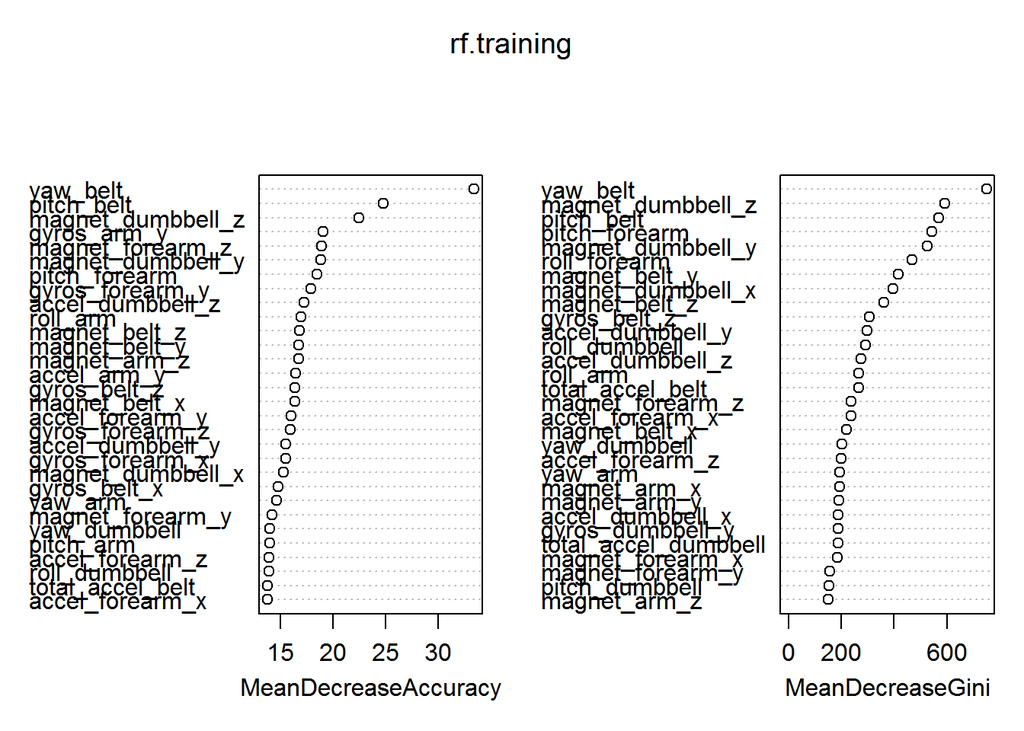

```r
varImpPlot(rf.training,)
```

```r
tree.pred=predict(rf.training,testing,type="class")
predMatrix = with(testing,table(tree.pred,classe))

#Error Rate
sum(diag(predMatrix))/sum(as.vector(predMatrix))
```

```
## [1] 0.9926933
```

# Print Answers

```r
answers <- predict(rf.training, testOrg)
answers
```

```
##  1  2  3  4  5  6  7  8  9 10 11 12 13 14 15 16 17 18 19 20
##  B  A  B  A  A  E  D  B  A  A  B  C  B  A  E  E  A  B  B  B
## Levels: A B C D E
```

```r
########### Writing Answers #############
write_files = function(x){
  len = length(x)
  for(i in 1:len){
    filename = paste0("problem_",i,".txt")
    write.table(x[i], file=filename, quote=FALSE, row.names=FALSE, col.names=FALSE)
  }
}
write_files(answers)
```

# Conclusion

A high level of accuracy has been observed